# DAV: Lab 4B

Clustering

2021

```r
knitr::opts_chunk$set(eval=params$answers, message=FALSE)
library(stylo)
library(psych)
library(factoextra)
library(dplyr)
```

For this lab you need the packages `stylo`, `psych`, and `factoextra`.

# Wine data

The `wine` data include 13 features of three different wine cultivars in Italy.

1. Load the `wine.Rdata` file in workspace, and display a summary of the `wine` data.

```r
load("data/wine.Rdata")
summary(wine)
```

```
##     Cultivar        Alcohol        Malic_acid         Ash
##  Min.   :1.000   Min.   :11.03   Min.   :0.740   Min.   :1.360
##  1st Qu.:1.000   1st Qu.:12.36   1st Qu.:1.603   1st Qu.:2.210
##  Median :2.000   Median :13.05   Median :1.865   Median :2.360
##  Mean   :1.938   Mean   :13.00   Mean   :2.336   Mean   :2.367
##  3rd Qu.:3.000   3rd Qu.:13.68   3rd Qu.:3.083   3rd Qu.:2.558
##  Max.   :3.000   Max.   :14.83   Max.   :5.800   Max.   :3.230
##    Alcalinity      Magnesium         Phenols        Flavanoids
##  Min.   :10.60   Min.   : 70.00   Min.   :0.980   Min.   :0.340
##  1st Qu.:17.20   1st Qu.: 88.00   1st Qu.:1.742   1st Qu.:1.205
##  Median :19.50   Median : 98.00   Median :2.355   Median :2.135
##  Mean   :19.49   Mean   : 99.74   Mean   :2.295   Mean   :2.029
##  3rd Qu.:21.50   3rd Qu.:107.00   3rd Qu.:2.800   3rd Qu.:2.875
##  Max.   :30.00   Max.   :162.00   Max.   :3.880   Max.   :5.080
##  Nonflavanoid_phenols Proanthocyanins Color_intensity       Hue
##  Min.   :0.1300       Min.   :0.410   Min.   : 1.280   Min.   :0.4800
##  1st Qu.:0.2700       1st Qu.:1.250   1st Qu.: 3.220   1st Qu.:0.7825
##  Median :0.3400       Median :1.555   Median : 4.690   Median :0.9650
##  Mean   :0.3619       Mean   :1.591   Mean   : 5.058   Mean   :0.9574
##  3rd Qu.:0.4375       3rd Qu.:1.950   3rd Qu.: 6.200   3rd Qu.:1.1200
##  Max.   :0.6600       Max.   :3.580   Max.   :13.000   Max.   :1.7100
##   OD280/OD315       Proline
##  Min.   :1.270   Min.   : 278.0
##  1st Qu.:1.938   1st Qu.: 500.5
##  Median :2.780   Median : 673.5
##  Mean   :2.612   Mean   : 746.9
##  3rd Qu.:3.170   3rd Qu.: 985.0
##  Max.   :4.000   Max.   :1680.0
```

2. Perform six k-means cluster analyses on the 13 (standardized) features (so exclude the variable `Cultivar`) with 1 to 6 to centers, respectively, and save the objects. Then plot the total within sum of squares of the six analyses to determine the optimal number of clusters.

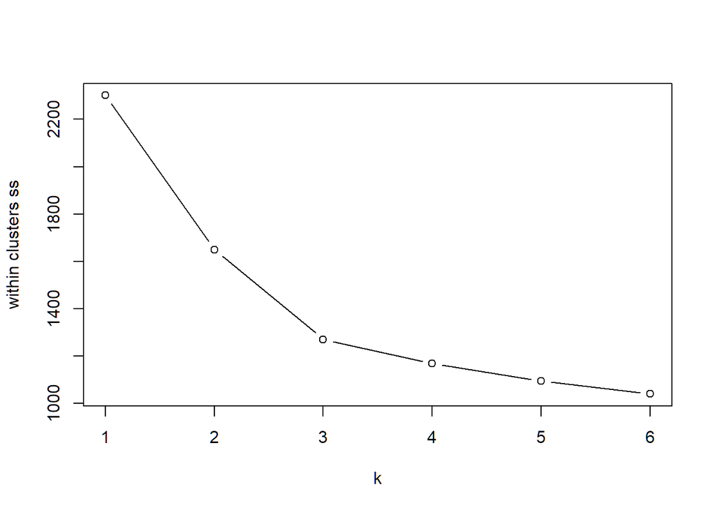

```r
set.seed(1)
k_1 <- kmeans(scale(wine[, -1]), centers = 1, nstart = 10)
k_2 <- kmeans(scale(wine[, -1]), centers = 2, nstart = 10)
k_3 <- kmeans(scale(wine[, -1]), centers = 3, nstart = 10)
k_4 <- kmeans(scale(wine[, -1]), centers = 4, nstart = 10)
k_5 <- kmeans(scale(wine[, -1]), centers = 5, nstart = 10)
k_6 <- kmeans(scale(wine[, -1]), centers = 6, nstart = 10)

plot(1:6,
       c(k_1$tot.withinss,
         k_2$tot.withinss,
         k_3$tot.withinss,
         k_4$tot.withinss,
         k_5$tot.withinss,
         k_6$tot.withinss),
     type = "b", ylab = "within clusters ss", xlab = "k")
```

3. Display a confusion matrix of the three clusters of the k-means analysis with three centers with the three levels of the variable `Cultivar` of the `wine` data. Did the cluster analysis recover the cultivars?

```r
table(obs = wine$Cultivar, est = k_3$cluster)
```

```
##    est
## obs  1  2  3
##   1 59  0  0
##   2  3 65  3
##   3  0  0 48
```

# Novels

In the previous lab we did a PCA on the frequently used words used in the novels by the Bronthe sister and Jane Austin. In this lab we perform a k-means analysis on these data.

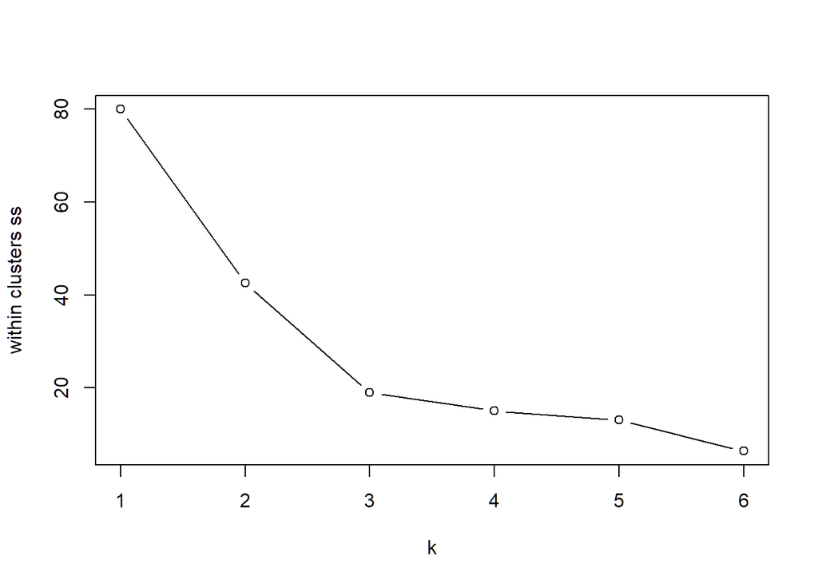

```r
k_1 <- kmeans(scale(freqs), centers = 1)
k_2 <- kmeans(scale(freqs), centers = 2)
k_3 <- kmeans(scale(freqs), centers = 3)
k_4 <- kmeans(scale(freqs), centers = 4)
k_5 <- kmeans(scale(freqs), centers = 5)
k_6 <- kmeans(scale(freqs), centers = 6)

plot(1:6,
       c(k_1$tot.withinss,
         k_2$tot.withinss,
         k_3$tot.withinss,
         k_4$tot.withinss,
         k_5$tot.withinss,
         k_6$tot.withinss),
     type = "b", ylab = "within clusters ss", xlab = "k")
```

```r
table(rownames(freqs), k_3$cluster)
```

```
##
##                     1 2 3
##   ABronte_Agnes     0 1 0
##   ABronte_Tenant    0 1 0
##   Austen_Emma       1 0 0
##   Austen_Pride      1 0 0
##   Austen_Sense      1 0 0
##   CBronte_Jane      0 0 1
##   CBronte_Professor 0 0 1
##   CBronte_Villette  0 0 1
##   EBronte_Wuthering 0 1 0
```

3. Visualize the clustering with the function `fviz_cluster` of the package `factoextra`. To make this function work, you first have to convert the class of the `freqs` object from `stylo.data` to `data.frame`.

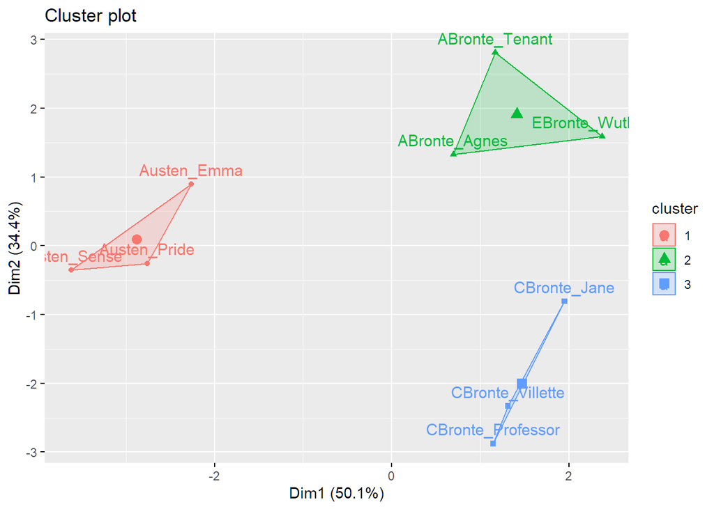

```r
fviz_cluster(k_3, scale(as.data.frame(unclass(freqs))))
```

4. Also perform a hierarchical clustering on the `freqs` data, and plot the dendogram, and add rectangles for 4 clusters. Do the clusters correspond to the authors?

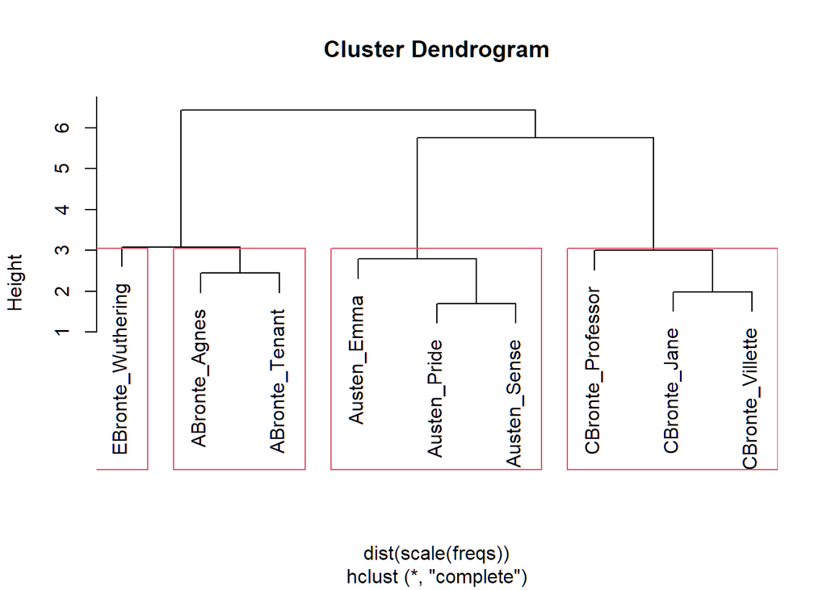

```r
cl <- hclust(dist(scale(freqs)))
plot(cl)
rect.hclust(cl, 4)
```

# Animals

1. Load `animals.Rdata` in workspace, and display the rownames and the summary of the `animals` data.

```r
load("animals.Rdata")
rownames(animals)
```

```
##  [1] "African giant pouched rat" "Asian elephant"
##  [3] "Baboon"                    "Big brown bat"
##  [5] "Brazilian tapir"           "Cat"
##  [7] "Chimpanzee"                "Chinchilla"
##  [9] "Cow"                       "Eastern American mole"
## [11] "Echidna"                   "European hedgehog"
## [13] "Galago"                    "Goat"
## [15] "Golden hamster"            "Gray seal"
## [17] "Ground squirrel"           "Guinea pig"
## [19] "Horse"                     "Lesser short-tailed shrew"
## [21] "Little brown bat"          "Man"
## [23] "Mouse"                     "Musk shrew"
## [25] "N. American opossum"       "Nine-banded armadillo"
## [27] "Owl monkey"                "Patas monkey"
## [29] "Phanlanger"                "Pig"
## [31] "Rabbit"                    "Rat"
## [33] "Red fox"                   "Rhesus monkey"
## [35] "Rock hyrax (Hetero. b)"    "Rock hyrax (Procavia hab)"
## [37] "Sheep"                     "Tenrec"
## [39] "Tree hyrax"                "Tree shrew"
## [41] "Vervet"                    "Water opossum"
```

```r
summary(animals)
```

```
##        bw                 brw               sws               ps
##  Min.   :   0.0050   Min.   :   0.14   Min.   : 2.100   Min.   :0.000
##  1st Qu.:   0.3162   1st Qu.:   3.60   1st Qu.: 6.150   1st Qu.:0.900
##  Median :   2.2500   Median :  12.20   Median : 8.500   Median :1.650
##  Mean   : 100.8139   Mean   : 218.68   Mean   : 8.743   Mean   :1.900
##  3rd Qu.:  10.4125   3rd Qu.: 155.50   3rd Qu.:11.000   3rd Qu.:2.375
##  Max.   :2547.0000   Max.   :4603.00   Max.   :17.900   Max.   :6.600
##        ts             mls               gt              pi
##  Min.   : 2.90   Min.   :  2.00   Min.   : 12.0   Min.   :1.000
##  1st Qu.: 8.05   1st Qu.:  5.25   1st Qu.: 32.0   1st Qu.:2.000
##  Median : 9.80   Median : 11.20   Median : 90.0   Median :3.000
##  Mean   :10.64   Mean   : 19.37   Mean   :129.9   Mean   :2.952
##  3rd Qu.:13.60   3rd Qu.: 27.00   3rd Qu.:195.0   3rd Qu.:4.000
##  Max.   :19.90   Max.   :100.00   Max.   :624.0   Max.   :5.000
##       sei             odi
##  Min.   :1.000   Min.   :1.00
##  1st Qu.:1.000   1st Qu.:1.25
##  Median :2.000   Median :2.50
##  Mean   :2.357   Mean   :2.69
##  3rd Qu.:3.750   3rd Qu.:4.00
##  Max.   :5.000   Max.   :5.00
```

2. Plot the dendograms of the hierarchical cluster analyses on the original `animals` data, one with the default linkage method “complete”, and one one with “ward.D2” (if you like, you can also look at other linkage methods). What do you expect to see, given that you did not standardize the features?

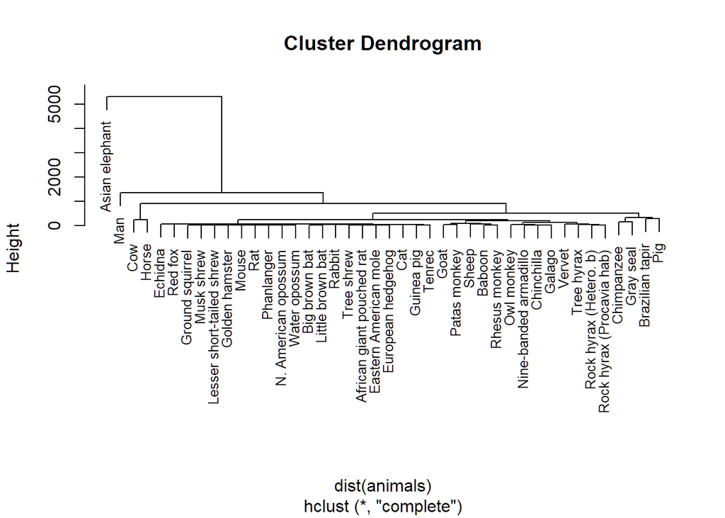

```r
plot(hclust(dist(animals), method = "complete"), cex = .8)
```

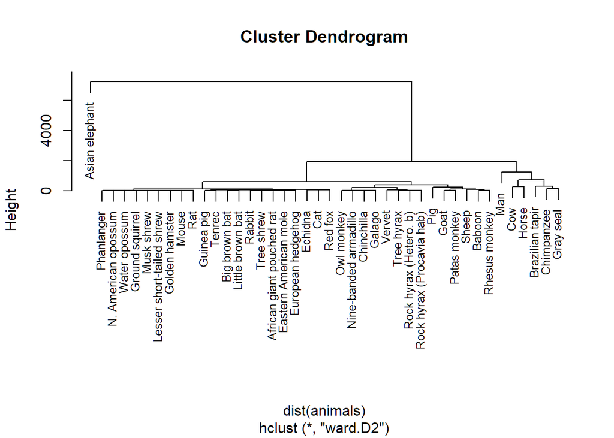

```r
plot(hclust(dist(animals), method = "ward.D2"),  cex = .8)
```

3. Re-plot the dendograms of the previous exercise , but now after standardizing the features? Does this improve the clustering?

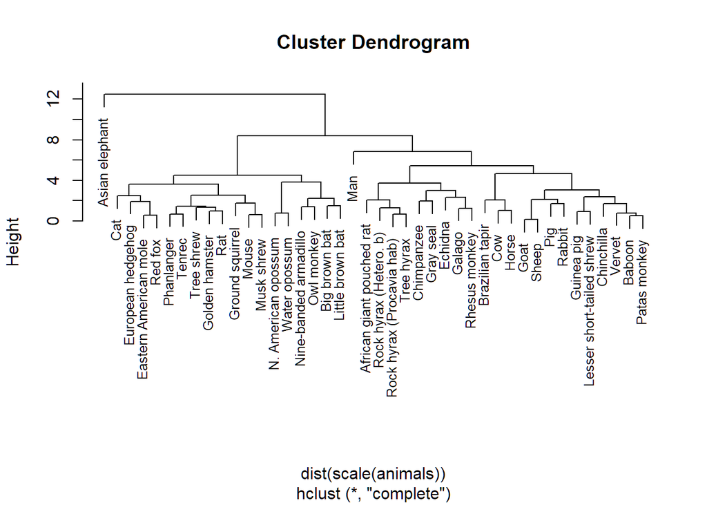

```r
plot(hclust(dist(scale(animals))), cex = .8)
```

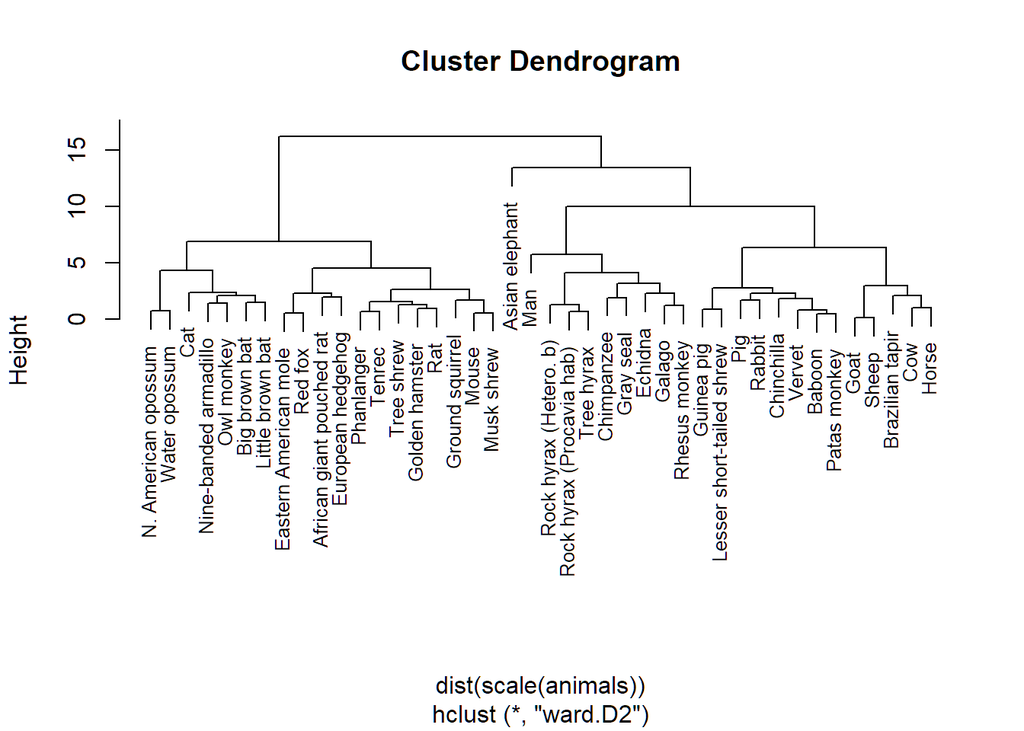

```r
plot(hclust(dist(scale(animals)), method = "ward.D2"), cex = .8)
```

4. Display boxplots of the standardized features. You will see that the 1st two features have an extremely skewed distribution.

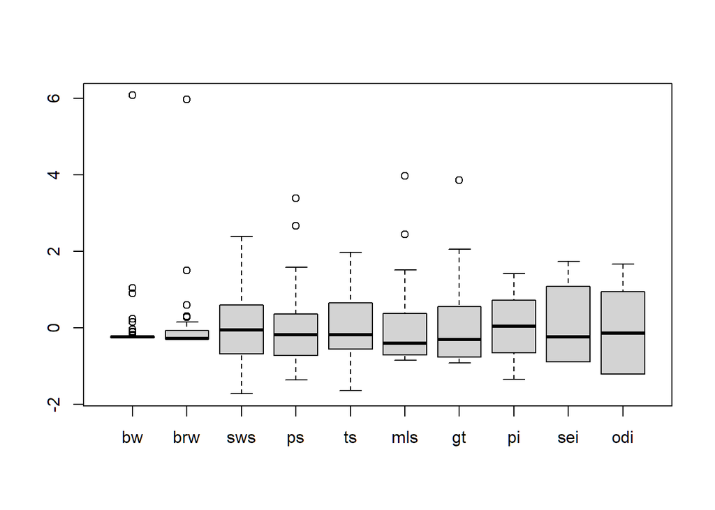

```r
boxplot(scale(animals))
```

6. Re-plot the dendograms of the standardized features, after applying a logarithmic transformation to the 1st two features of `animals`.

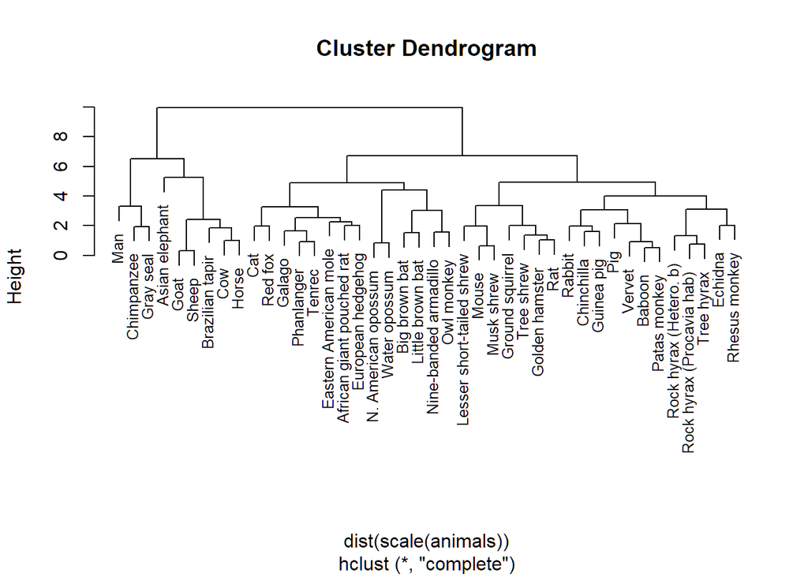

```r
animals <- animals %>% mutate_at(vars(bw, brw), log)

plot(hclust(dist(scale(animals))), cex = .8)
```

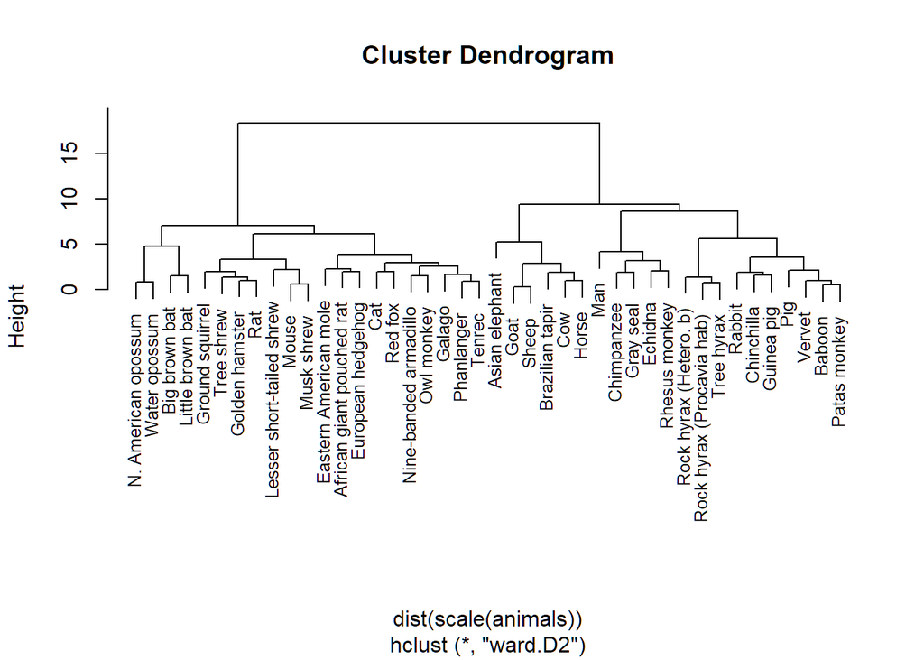

```r
plot(hclust(dist(scale(animals)), method = "ward.D2"), cex = .8)
```

5. Which of the taxonomies you created above do you like best?

END OF LAB